# RegressionProject

Rohith Anugolu

Friday, August 01, 2025

**Research question:** **Can carat weight of a diamond be determined from visually observable characteristics** **i.e. without actually weighing the diamond. Note: Price is not observable, so do not use price.** **Come up with a way to ascertain the carat weight of a diamond without physically touching it. All other variables in the dataset can be determined visually.**

**Load necessary packages**

```r
library(tidyverse)
library(tidymodels)
library(ggplot2)
library(mosaic)
library(GGally)
library(caret)
```

```r
# Let's make a residual.analysis function to save typing.
residualAnalysis <- function(model=NULL) {
if(!require(gridExtra)) stop('Install the gridExtra package.')
if(!require(ggformula)) stop('Install the ggformula package.')
df <- data.frame(Prediction=predict(model$fit),
Residual=rstandard(model$fit))
p1 <- gf_point(Residual~Prediction,data=df) %>% gf_hline(yintercept = 0)
p2 <- gf_qq(~Residual,data=df) %>% gf_qqline()
grid.arrange(p1, p2, ncol=2)
}
```

```r
head(diamonds)
```

```
## # A tibble: 6 × 10
##   carat cut       color clarity depth table price     x     y     z
##   <dbl> <ord>     <ord> <ord>   <dbl> <dbl> <int> <dbl> <dbl> <dbl>
## 1  0.23 Ideal     E     SI2      61.5    55   326  3.95  3.98  2.43
## 2  0.21 Premium   E     SI1      59.8    61   326  3.89  3.84  2.31
## 3  0.23 Good      E     VS1      56.9    65   327  4.05  4.07  2.31
## 4  0.29 Premium   I     VS2      62.4    58   334  4.2   4.23  2.63
## 5  0.31 Good      J     SI2      63.3    58   335  4.34  4.35  2.75
## 6  0.24 Very Good J     VVS2     62.8    57   336  3.94  3.96  2.48
```

**We are going to check the quantitative variables of the data set**

```r
quant <- sapply(diamonds, is.numeric)
names(diamonds)[quant]
```

```
## [1] "carat" "depth" "table" "price" "x"     "y"     "z"
```

**Weight of a carat is closely related to the volume so we try to create `volume` feature. First we check the pairwise correlation between `carat`,`x`,`y`,`z`**

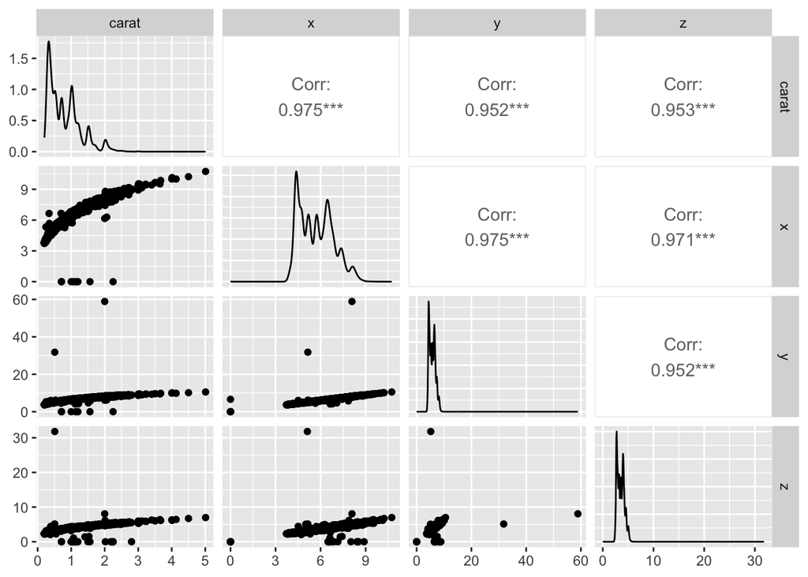

```r
diamonds %>%
  select(carat,x,y,z) %>%
  ggpairs()
```

**`x`,`y`,`z` have high correlation with `carat` with the first look it is a good indication but we will confirm further if it is a good measure.**

**Question: Can volume be used as a good predictor for carat?** Let us now calculate the volume

```r
diamonds %>%
  mutate(volume = x*y*z) -> diamonds

head(diamonds)
```

```
## # A tibble: 6 × 11
##   carat cut       color clarity depth table price     x     y     z volume
##   <dbl> <ord>     <ord> <ord>   <dbl> <dbl> <int> <dbl> <dbl> <dbl>  <dbl>
## 1  0.23 Ideal     E     SI2      61.5    55   326  3.95  3.98  2.43   38.2
## 2  0.21 Premium   E     SI1      59.8    61   326  3.89  3.84  2.31   34.5
## 3  0.23 Good      E     VS1      56.9    65   327  4.05  4.07  2.31   38.1
## 4  0.29 Premium   I     VS2      62.4    58   334  4.2   4.23  2.63   46.7
## 5  0.31 Good      J     SI2      63.3    58   335  4.34  4.35  2.75   51.9
## 6  0.24 Very Good J     VVS2     62.8    57   336  3.94  3.96  2.48   38.7
```

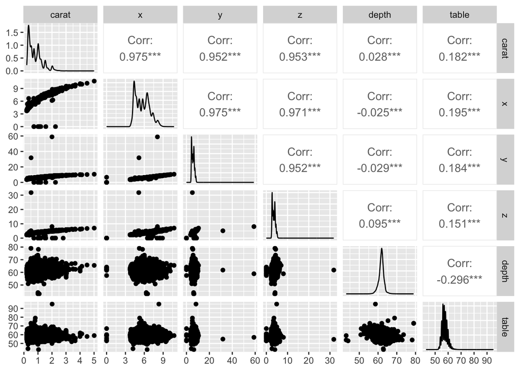

```r
diamonds %>%
  select(carat,x,y,z, depth,table) %>%
  ggpairs()
```

**`depth` & `table` have a weak correlation with carat. They will not be used in the model**

```r
diamonds <- diamonds %>%
  mutate(
    quality_cut = if_else(cut %in% c("Ideal", "Premium"), "High", "Low"),
    quality_color = if_else(color %in% c("D", "E", "F"), "High", "Low"),
    quality_clarity = if_else(clarity %in% c("IF", "VVS1", "VVS2"), "High", "Low")
  )
diamonds <- diamonds %>%
  mutate(
    quality_cut = as.factor(quality_cut),
    quality_color = as.factor(quality_color),
    quality_clarity = as.factor(quality_clarity)
  )
head(diamonds)
```

```
## # A tibble: 6 × 14
##   carat cut       color clarity depth table price     x     y     z volume
##   <dbl> <ord>     <ord> <ord>   <dbl> <dbl> <int> <dbl> <dbl> <dbl>  <dbl>
## 1  0.23 Ideal     E     SI2      61.5    55   326  3.95  3.98  2.43   38.2
## 2  0.21 Premium   E     SI1      59.8    61   326  3.89  3.84  2.31   34.5
## 3  0.23 Good      E     VS1      56.9    65   327  4.05  4.07  2.31   38.1
## 4  0.29 Premium   I     VS2      62.4    58   334  4.2   4.23  2.63   46.7
## 5  0.31 Good      J     SI2      63.3    58   335  4.34  4.35  2.75   51.9
## 6  0.24 Very Good J     VVS2     62.8    57   336  3.94  3.96  2.48   38.7
## # ℹ 3 more variables: quality_cut <fct>, quality_color <fct>,
## #   quality_clarity <fct>
```

**Visualizing the relationships of the created predictors**

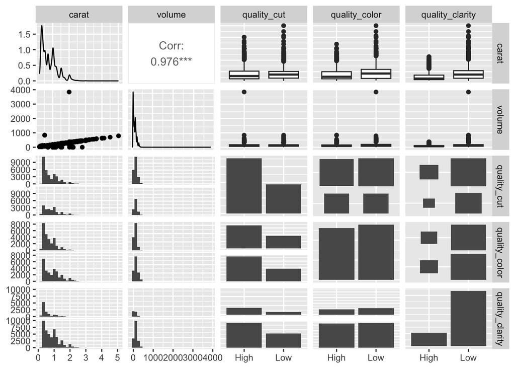

```r
diamonds %>%
  select(carat, volume, quality_cut, quality_color, quality_clarity) %>%
ggpairs()
```

## Train-Test Split

**Spliting the data into training and test sets**

```r
set.seed(2025)
diamonds_split <- createDataPartition(diamonds$carat, p = 0.80, list = FALSE)

train_data <- diamonds[diamonds_split,]
test_data <- diamonds[-diamonds_split,]

train_data
```

```
## # A tibble: 43,154 × 14
##    carat cut       color clarity depth table price     x     y     z volume
##    <dbl> <ord>     <ord> <ord>   <dbl> <dbl> <int> <dbl> <dbl> <dbl>  <dbl>
##  1  0.21 Premium   E     SI1      59.8    61   326  3.89  3.84  2.31   34.5
##  2  0.23 Good      E     VS1      56.9    65   327  4.05  4.07  2.31   38.1
##  3  0.29 Premium   I     VS2      62.4    58   334  4.2   4.23  2.63   46.7
##  4  0.31 Good      J     SI2      63.3    58   335  4.34  4.35  2.75   51.9
##  5  0.24 Very Good J     VVS2     62.8    57   336  3.94  3.96  2.48   38.7
##  6  0.26 Very Good H     SI1      61.9    55   337  4.07  4.11  2.53   42.3
##  7  0.22 Fair      E     VS2      65.1    61   337  3.87  3.78  2.49   36.4
##  8  0.23 Very Good H     VS1      59.4    61   338  4     4.05  2.39   38.7
##  9  0.23 Ideal     J     VS1      62.8    56   340  3.93  3.9   2.46   37.7
## 10  0.22 Premium   F     SI1      60.4    61   342  3.88  3.84  2.33   34.7
## # ℹ 43,144 more rows
## # ℹ 3 more variables: quality_cut <fct>, quality_color <fct>,
## #   quality_clarity <fct>
```

```r
test_data
```

```
## # A tibble: 10,786 × 14
##    carat cut       color clarity depth table price     x     y     z volume
##    <dbl> <ord>     <ord> <ord>   <dbl> <dbl> <int> <dbl> <dbl> <dbl>  <dbl>
##  1  0.23 Ideal     E     SI2      61.5    55   326  3.95  3.98  2.43   38.2
##  2  0.24 Very Good I     VVS1     62.3    57   336  3.95  3.98  2.47   38.8
##  3  0.3  Good      J     SI1      64      55   339  4.25  4.28  2.73   49.7
##  4  0.2  Premium   E     SI2      60.2    62   345  3.79  3.75  2.27   32.3
##  5  0.23 Very Good H     VS1      61      57   353  3.94  3.96  2.41   37.6
##  6  0.31 Very Good J     SI1      59.4    62   353  4.39  4.43  2.62   51.0
##  7  0.23 Very Good G     VVS2     60.4    58   354  3.97  4.01  2.41   38.4
##  8  0.24 Premium   I     VS1      62.5    57   355  3.97  3.94  2.47   38.6
##  9  0.23 Very Good F     VS1      60      57   402  4     4.03  2.41   38.8
## 10  0.33 Ideal     I     SI2      61.8    55   403  4.49  4.51  2.78   56.3
## # ℹ 10,776 more rows
## # ℹ 3 more variables: quality_cut <fct>, quality_color <fct>,
## #   quality_clarity <fct>
```

## Multiple Linear Regression

### Using backward selection to identify predictors contributing to the model

```r
lm_spec <- linear_reg() %>%
  set_mode("regression") %>%
  set_engine("lm")

back_selection <- lm_spec |>
    fit(carat ~ volume + quality_cut + quality_color + quality_clarity,
                data = train_data)

tidy(back_selection$fit)
```

```
## # A tibble: 5 × 5
##   term               estimate  std.error statistic  p.value
##   <chr>                 <dbl>      <dbl>     <dbl>    <dbl>
## 1 (Intercept)         0.0152  0.00147         10.4 3.79e-25
## 2 volume              0.00580 0.00000723     803.  0
## 3 quality_cutLow      0.0127  0.00113         11.3 2.16e-29
## 4 quality_colorLow    0.0149  0.00110         13.5 9.89e-42
## 5 quality_clarityLow  0.0217  0.00140         15.5 6.06e-54
```

```r
glance(back_selection$fit)
```

```
## # A tibble: 1 × 12
##   r.squared adj.r.squared sigma statistic p.value    df logLik     AIC     BIC
##       <dbl>         <dbl> <dbl>     <dbl>   <dbl> <dbl>  <dbl>   <dbl>   <dbl>
## 1     0.945         0.945 0.111   185796.       0     4 33687. -67362. -67309.
## # ℹ 3 more variables: deviance <dbl>, df.residual <int>, nobs <int>
```

### Multiple Linear Regression (reduced model)

Creating lm_model

```r
lm_spec <- linear_reg() %>%
  set_mode("regression") %>%
  set_engine("lm")

mlr_mod <- lm_spec %>%
  fit(carat ~ volume * quality_cut + quality_clarity, data = train_data)

tidy(mlr_mod)
```

```
## # A tibble: 5 × 5
##   term                   estimate  std.error statistic   p.value
##   <chr>                     <dbl>      <dbl>     <dbl>     <dbl>
## 1 (Intercept)            0.0418   0.00149         28.0 2.29e-171
## 2 volume                 0.00566  0.00000828     684.  0
## 3 quality_cutLow        -0.0563   0.00222        -25.3 1.11e-140
## 4 quality_clarityLow     0.0200   0.00138         14.5 1.15e- 47
## 5 volume:quality_cutLow  0.000516 0.0000145       35.6 3.94e-274
```

### Check the assumptions

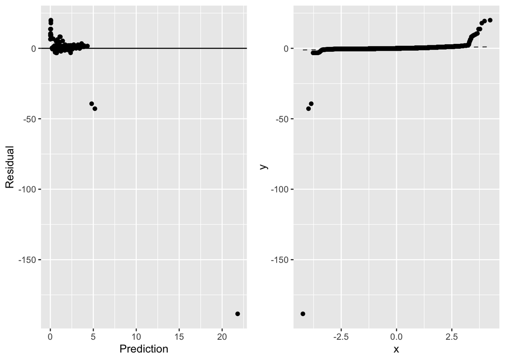

```r
residualAnalysis(mlr_mod)
```

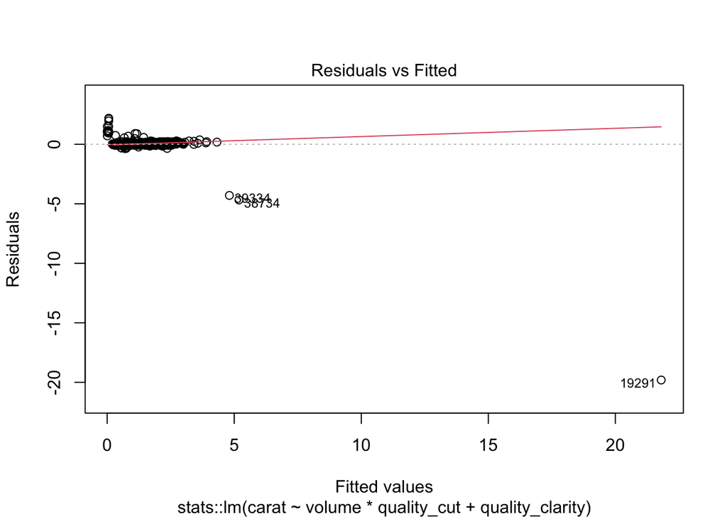

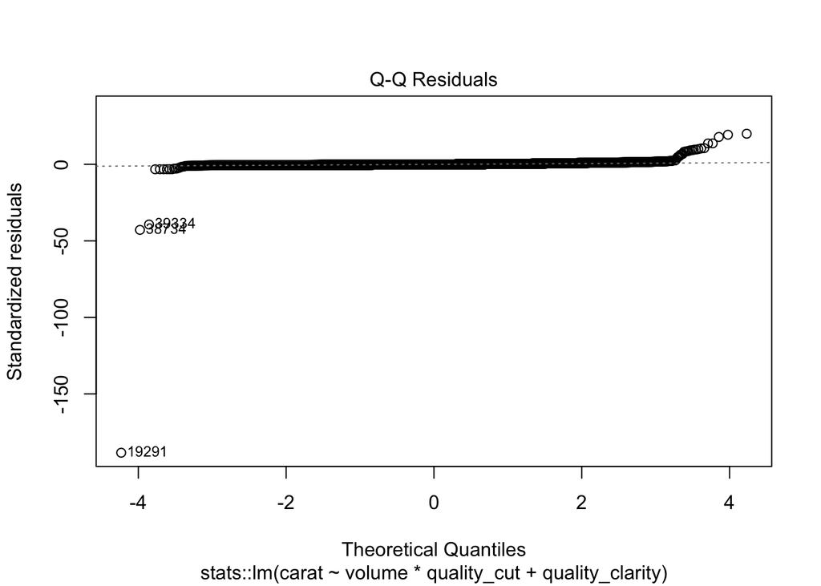

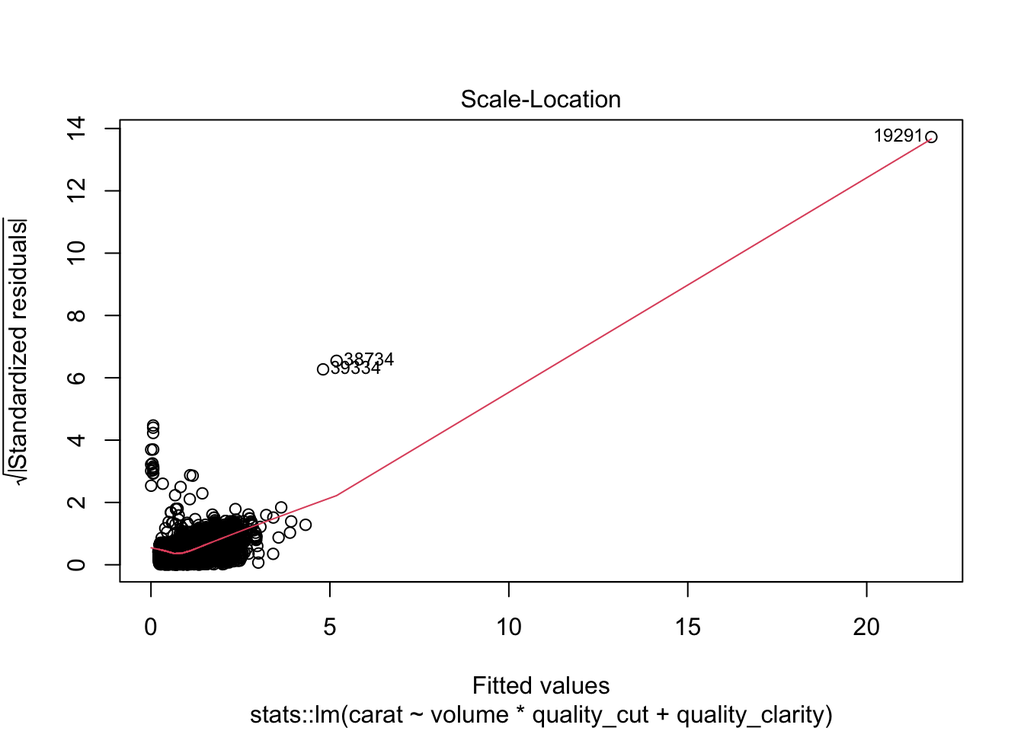

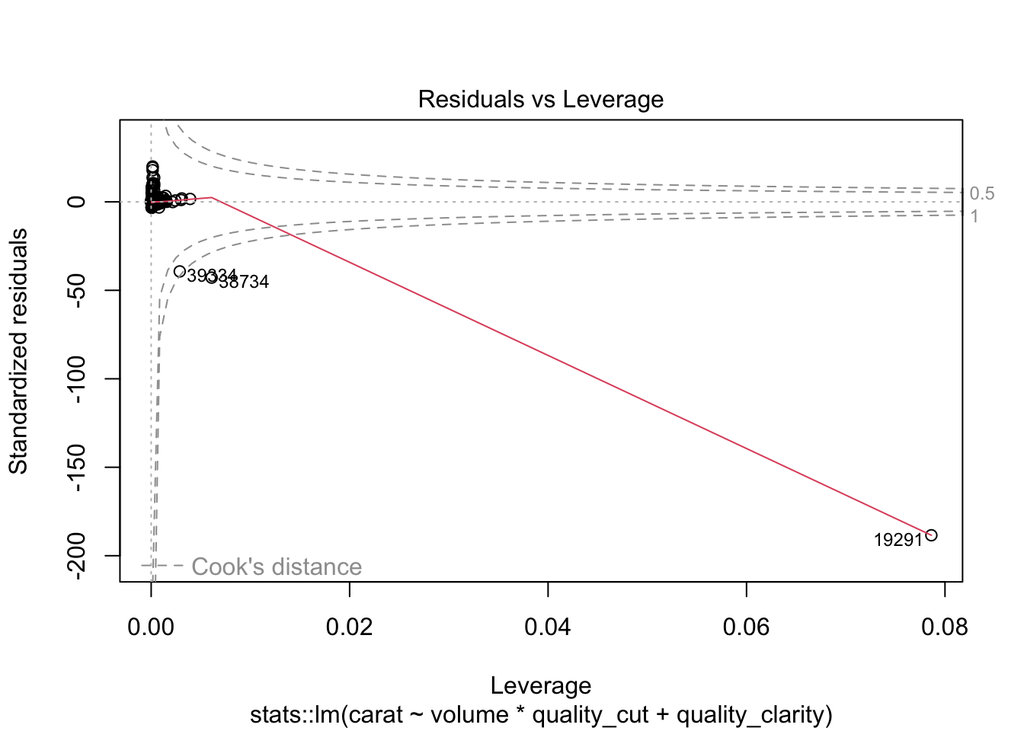

```r
plot(mlr_mod$fit)
```

### Confidence Intervals

```r
confint(mlr_mod$fit, level = 0.95)
```

```
##                               2.5 %        97.5 %
## (Intercept)            0.0389156907  0.0447668490
## volume                 0.0056452828  0.0056777474
## quality_cutLow        -0.0606570282 -0.0519486602
## quality_clarityLow     0.0172907494  0.0226868110
## volume:quality_cutLow  0.0004877515  0.0005445303
```

```r
predictions <- augment(mlr_mod, new_data = test_data)
predictions
```

```
## # A tibble: 10,786 × 16
##    .pred   .resid carat cut    color clarity depth table price     x     y     z
##    <dbl>    <dbl> <dbl> <ord>  <ord> <ord>   <dbl> <dbl> <int> <dbl> <dbl> <dbl>
##  1 0.278 -0.0481   0.23 Ideal  E     SI2      61.5    55   326  3.95  3.98  2.43
##  2 0.225  0.0146   0.24 Very … I     VVS1     62.3    57   336  3.95  3.98  2.47
##  3 0.312 -0.0123   0.3  Good   J     SI1      64      55   339  4.25  4.28  2.73
##  4 0.244 -0.0445   0.2  Premi… E     SI2      60.2    62   345  3.79  3.75  2.27
##  5 0.238 -0.00782  0.23 Very … H     VS1      61      57   353  3.94  3.96  2.41
##  6 0.320 -0.0103   0.31 Very … J     SI1      59.4    62   353  4.39  4.43  2.62
##  7 0.223  0.00745  0.23 Very … G     VVS2     60.4    58   354  3.97  4.01  2.41
##  8 0.281 -0.0406   0.24 Premi… I     VS1      62.5    57   355  3.97  3.94  2.47
##  9 0.246 -0.0155   0.23 Very … F     VS1      60      57   402  4     4.03  2.41
## 10 0.381 -0.0505   0.33 Ideal  I     SI2      61.8    55   403  4.49  4.51  2.78
## # ℹ 10,776 more rows
## # ℹ 4 more variables: volume <dbl>, quality_cut <fct>, quality_color <fct>,
## #   quality_clarity <fct>
```

### Model fit

```r
model_summary <- glance(mlr_mod)
print(model_summary)
```

```
## # A tibble: 1 × 12
##   r.squared adj.r.squared sigma statistic p.value    df logLik     AIC     BIC
##       <dbl>         <dbl> <dbl>     <dbl>   <dbl> <dbl>  <dbl>   <dbl>   <dbl>
## 1     0.946         0.946 0.109   190724.       0     4 34221. -68430. -68378.
## # ℹ 3 more variables: deviance <dbl>, df.residual <int>, nobs <int>
```

### Confidence & Prediction Intervals on test data

```r
pred_intervals <- cbind(
  test_data,
  predict(mlr_mod, new_data=test_data),
  predict(mlr_mod, new_data=test_data, type="conf_int"),
  predict(mlr_mod, new_data=test_data, type="pred_int"))

colnames(pred_intervals) <- make.unique(names(pred_intervals))

pred_intervals <- pred_intervals |>
  rename(.conf_lower = .pred_lower, .conf_upper = .pred_upper, .pred_lower = .pred_lower.1, .pred_upper = .pred_upper.1)
```

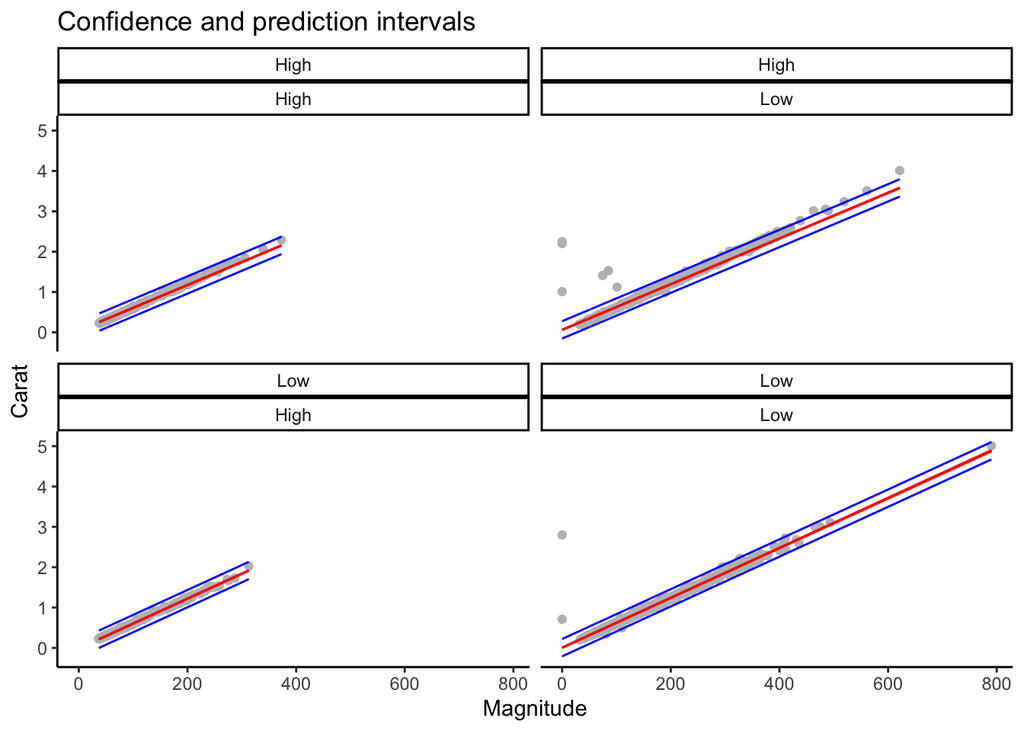

```r
pred_intervals |>
  gf_point(carat ~ volume, col = "grey") |>
  gf_line(.pred ~ volume) |>
  gf_line(.conf_lower ~ volume, col='red') %>%
  gf_line(.conf_upper ~ volume, col='red') %>%
  gf_line(.pred_lower ~ volume, col='blue') %>%
  gf_line(.pred_upper ~ volume, col='blue') +
  facet_wrap(~ quality_cut + quality_clarity) +
  gf_theme(theme_classic()) +
  labs(title = "Confidence and prediction intervals", x = "Magnitude", y = "Carat")
```

## Polynomial Regression

**Data to use for the model**

```r
polData <- diamonds %>%
  select(carat,table,depth,x,y,z)
```

### Identifying skewness through Histogram

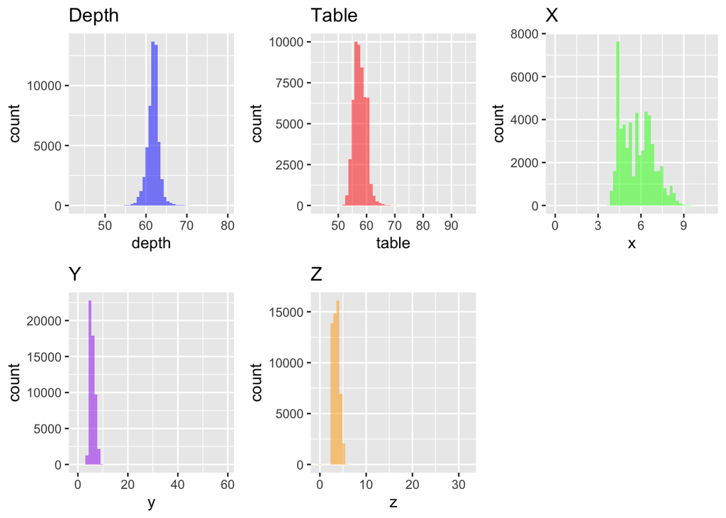

```r
library(gridExtra)
dPlot <- ggplot(polData, aes(x = depth)) + geom_histogram(bins = 50, fill="blue", alpha=0.5) + ggtitle("Depth")
tPlot <- ggplot(polData, aes(x = table)) + geom_histogram(bins = 50, fill="red", alpha=0.5) + ggtitle("Table")
xPlot <- ggplot(polData, aes(x = x)) + geom_histogram(bins = 50, fill="green", alpha=0.5) + ggtitle("X")
yPlot <- ggplot(polData, aes(x = y)) + geom_histogram(bins = 50, fill="purple", alpha=0.5) + ggtitle("Y")
zPlot <- ggplot(polData, aes(x = z)) + geom_histogram(bins = 50, fill="orange", alpha=0.5) + ggtitle("Z")

grid.arrange(dPlot, tPlot, xPlot, yPlot, zPlot, ncol=3)
```

**`depth` and `table` have an appproximate normal distribution so there is no need for log transformation. `x` has slight skewed and log transformation might help,`y`,`z` are strong right-skewed so we implement log transformation.**

```r
polData <- diamonds %>%
  mutate(
    log_x = log(x+1),
    log_y = log(y+1),
    log_z = log(z+1)
  )
```

```r
skimr::skim(polData) |>
  select(-numeric.hist)
```

Data summary

| Name | polData |
| --- | --- |
| Number of rows | 53940 |
| Number of columns | 17 |
| _______________________ |  |
| Column type frequency: |  |
| factor | 6 |
| numeric | 11 |
| ________________________ |  |
| Group variables | None |

**Variable type: factor**

| skim_variable | n_missing | complete_rate | ordered | n_unique | top_counts |
| --- | --- | --- | --- | --- | --- |
| cut | 0 | 1 | TRUE | 5 | Ide: 21551, Pre: 13791, Ver: 12082, Goo: 4906 |
| color | 0 | 1 | TRUE | 7 | G: 11292, E: 9797, F: 9542, H: 8304 |
| clarity | 0 | 1 | TRUE | 8 | SI1: 13065, VS2: 12258, SI2: 9194, VS1: 8171 |
| quality_cut | 0 | 1 | FALSE | 2 | Hig: 35342, Low: 18598 |
| quality_color | 0 | 1 | FALSE | 2 | Low: 27826, Hig: 26114 |
| quality_clarity | 0 | 1 | FALSE | 2 | Low: 43429, Hig: 10511 |

**Variable type: numeric**

| skim_variable | n_missing | complete_rate | mean | sd | p0 | p25 | p50 | p75 | p100 |
| --- | --- | --- | --- | --- | --- | --- | --- | --- | --- |
| carat | 0 | 1 | 0.80 | 0.47 | 0.2 | 0.40 | 0.70 | 1.04 | 5.01 |
| depth | 0 | 1 | 61.75 | 1.43 | 43.0 | 61.00 | 61.80 | 62.50 | 79.00 |
| table | 0 | 1 | 57.46 | 2.23 | 43.0 | 56.00 | 57.00 | 59.00 | 95.00 |
| price | 0 | 1 | 3932.80 | 3989.44 | 326.0 | 950.00 | 2401.00 | 5324.25 | 18823.00 |
| x | 0 | 1 | 5.73 | 1.12 | 0.0 | 4.71 | 5.70 | 6.54 | 10.74 |
| y | 0 | 1 | 5.73 | 1.14 | 0.0 | 4.72 | 5.71 | 6.54 | 58.90 |
| z | 0 | 1 | 3.54 | 0.71 | 0.0 | 2.91 | 3.53 | 4.04 | 31.80 |
| volume | 0 | 1 | 129.85 | 78.25 | 0.0 | 65.14 | 114.81 | 170.84 | 3840.60 |
| log_x | 0 | 1 | 1.89 | 0.17 | 0.0 | 1.74 | 1.90 | 2.02 | 2.46 |
| log_y | 0 | 1 | 1.89 | 0.17 | 0.0 | 1.74 | 1.90 | 2.02 | 4.09 |
| log_z | 0 | 1 | 1.50 | 0.15 | 0.0 | 1.36 | 1.51 | 1.62 | 3.49 |

### Train - Test Split

```r
set.seed(2025)
library(caret)
trainIndex <- createDataPartition(polData$carat, p = 0.8, list = FALSE)
trainData <- polData[trainIndex, ]
testData  <- polData[-trainIndex, ]
```

**Let us fit a polynomial regression model**

```r
polyModel <- lm(carat ~ poly(x, 2, raw = TRUE) +
                  poly(y, 2, raw = TRUE) +
                  poly(z, 2, raw = TRUE) +
                  depth + table,
                data = trainData)

summary(polyModel)
```

```
##
## Call:
## lm(formula = carat ~ poly(x, 2, raw = TRUE) + poly(y, 2, raw = TRUE) +
##     poly(z, 2, raw = TRUE) + depth + table, data = trainData)
##
## Residuals:
##      Min       1Q   Median       3Q      Max
## -0.84274 -0.01088  0.00077  0.01058  1.39765
##
## Coefficients:
##                           Estimate Std. Error t value Pr(>|t|)
## (Intercept)             -4.213e-01  1.042e-02  -40.42   <2e-16 ***
## poly(x, 2, raw = TRUE)1 -5.448e-01  2.268e-03 -240.20   <2e-16 ***
## poly(x, 2, raw = TRUE)2  7.233e-02  9.928e-05  728.58   <2e-16 ***
## poly(y, 2, raw = TRUE)1  6.781e-02  1.710e-03   39.65   <2e-16 ***
## poly(y, 2, raw = TRUE)2 -1.105e-03  2.811e-05  -39.30   <2e-16 ***
## poly(z, 2, raw = TRUE)1  8.552e-02  2.276e-03   37.57   <2e-16 ***
## poly(z, 2, raw = TRUE)2 -2.274e-03  7.210e-05  -31.53   <2e-16 ***
## depth                    1.735e-02  1.414e-04  122.69   <2e-16 ***
## table                    3.124e-03  6.208e-05   50.32   <2e-16 ***
## ---
## Signif. codes:  0 '***' 0.001 '**' 0.01 '*' 0.05 '.' 0.1 ' ' 1
##
## Residual standard error: 0.02675 on 43145 degrees of freedom
## Multiple R-squared:  0.9968, Adjusted R-squared:  0.9968
## F-statistic: 1.683e+06 on 8 and 43145 DF,  p-value: < 2.2e-16
```

### Making Predictions on test data

```r
testData$predicted <- predict(polyModel, testData)
```

```r
rmse <- sqrt(mean((testData$predicted - testData$carat)^2))
print(paste("Test RMSE:", round(rmse, 4)))
```

```
## [1] "Test RMSE: 0.0261"
```

**The Root Mean Squared Error on the test data is smaller than Residual Standard Error which shows there is no overfitting in the model.**

### Confidence Intervals

```r
confint(polyModel, level = 0.95)
```

```
##                                2.5 %       97.5 %
## (Intercept)             -0.441743726 -0.400881835
## poly(x, 2, raw = TRUE)1 -0.549243937 -0.540352968
## poly(x, 2, raw = TRUE)2  0.072137952  0.072527128
## poly(y, 2, raw = TRUE)1  0.064457565  0.071161281
## poly(y, 2, raw = TRUE)2 -0.001159767 -0.001049584
## poly(z, 2, raw = TRUE)1  0.081058276  0.089982175
## poly(z, 2, raw = TRUE)2 -0.002414982 -0.002132332
## depth                    0.017069281  0.017623497
## table                    0.003002130  0.003245500
```

### Check the assumptions

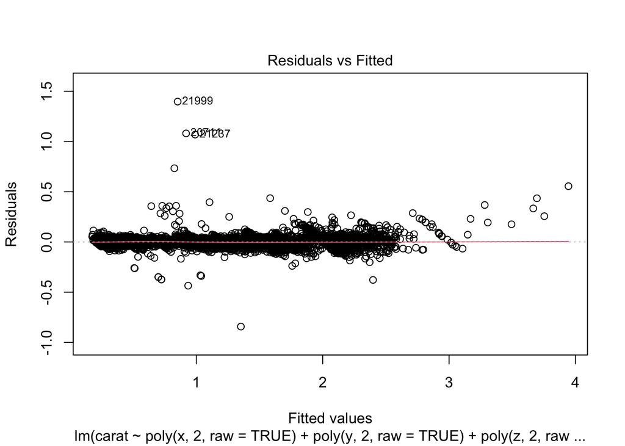

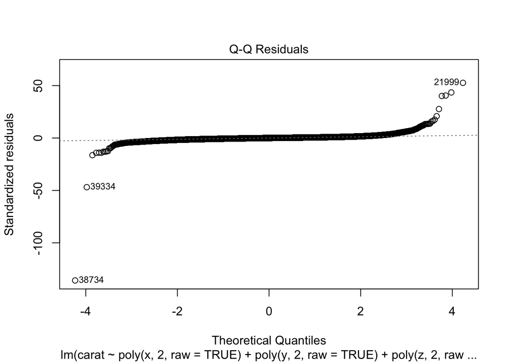

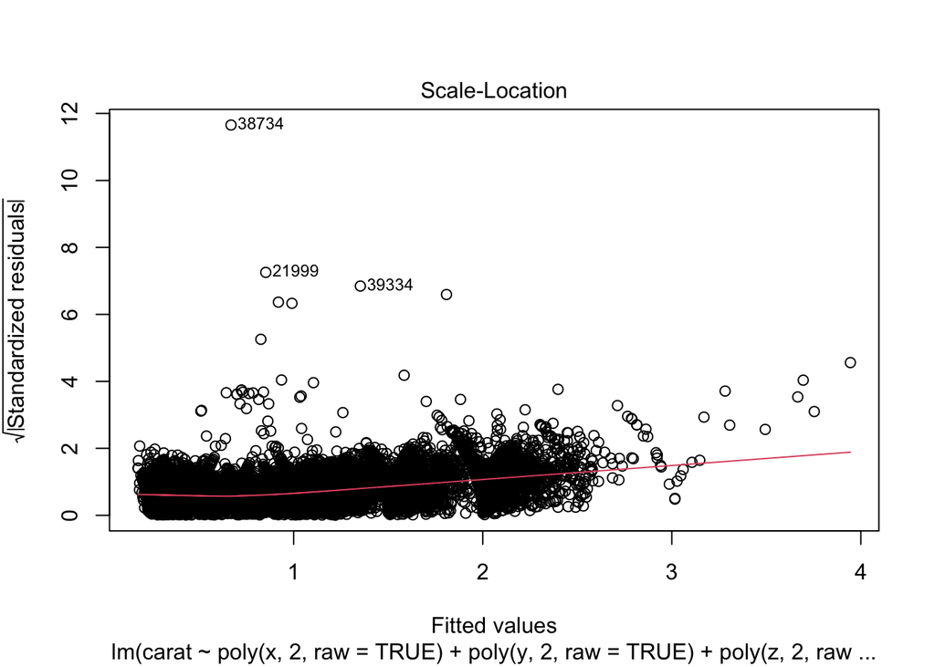

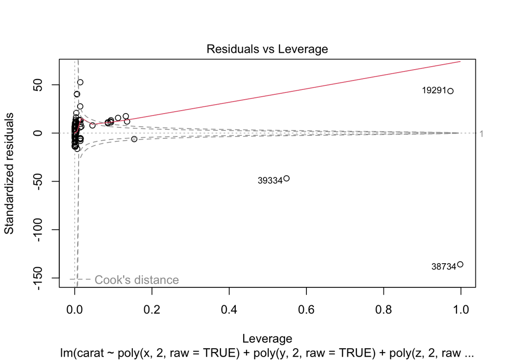

```r
plot(polyModel)
```